# Rochester Region Federal Funds Dashboard Mockup

Federal COVID-19 pandemic-response packages have provided unprecedented aid to state and local governments, including $800 billion that can be used flexibly to promote an inclusive recovery. These resources create an unparalleled opportunity for advocates and local decision-makers to ensure federal funds reach communities that need them most, close equity gaps exacerbated by the pandemic, and address the root causes of inequities. To take advantage of this opportunity, local leaders need timely data and evidence to ensure funds are used effectively and equitably.

This dashboard tracks the federal recovery funds flowing into the City of Rochester and Monroe County that can be used for inclusive recovery efforts. The dashboard primarily tracks appropriations, or how much funding the federal government has committed to provide local jurisdictions. For a few select programs where information is available, the dashboard also explores spending by zip code.

## Total Funding by Policy Area

Overall, 286M of funds have been allocated to the city of Rochester and Monroe County, and 8% have been reported as spent. By category, **most** of the funds have been allocated to **Community and Economic Development, Infrastructure, and Housing**, while the **least** have been allocated to **Operations, Public Safety, and Social Services**:

**Allocated**

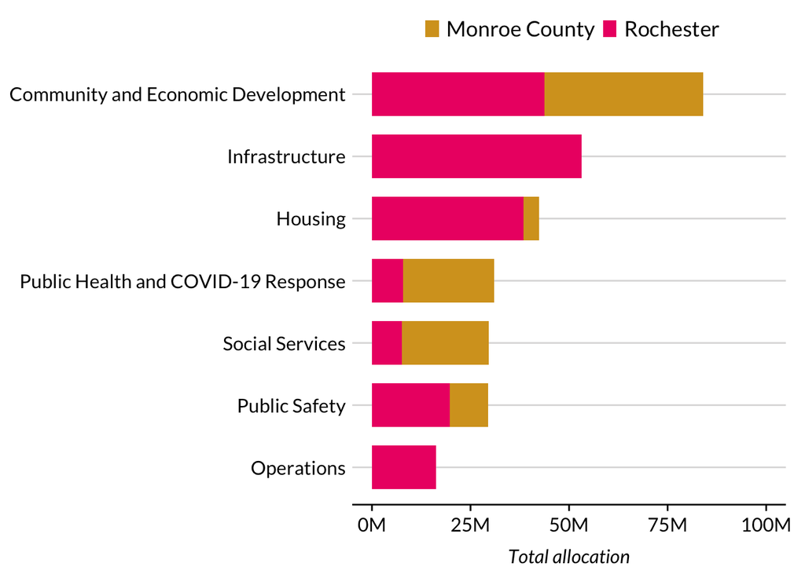

**Spent**

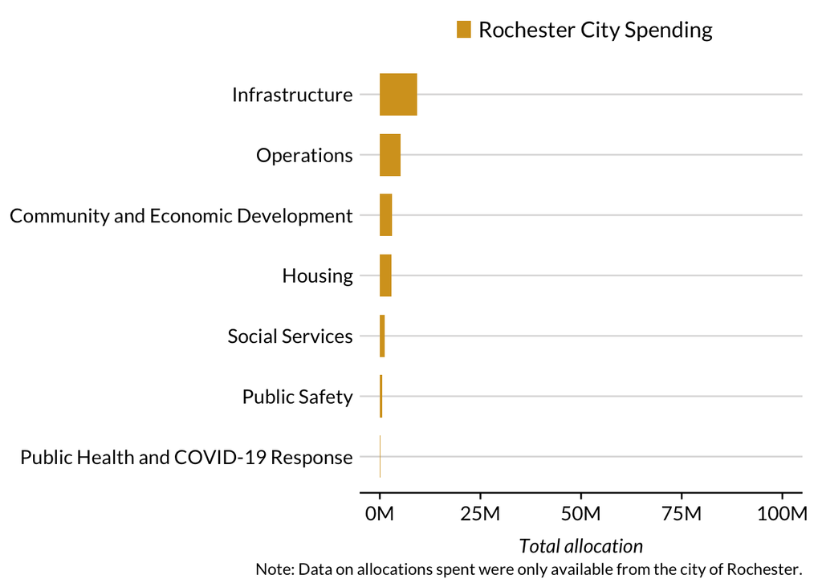

## How Much is Being Spent on an Inclusive Recovery?

Broadly, there are [five building blocks](https://www.urban.org/research/publication/aligning-use-recovery-funds-community-goals-rochester-new-york) of an inclusive recovery:

1. **Create jobs** for residents hardest hit by the pandemic or who face the greatest barriers to employment
2. **Connect residents to jobs** and economic opportunities, including through workforce development, child care, transportation, or broadband
3. **Reinvest in disinvested communities** and address long-standing disparities in access to education, capital, economic opportunities, and climate resilience
4. **Stabilize housing and expand affordable housing**options for low-income households and housing-insecure renters
5. Create opportunities for low-wealth households to **build wealth**.

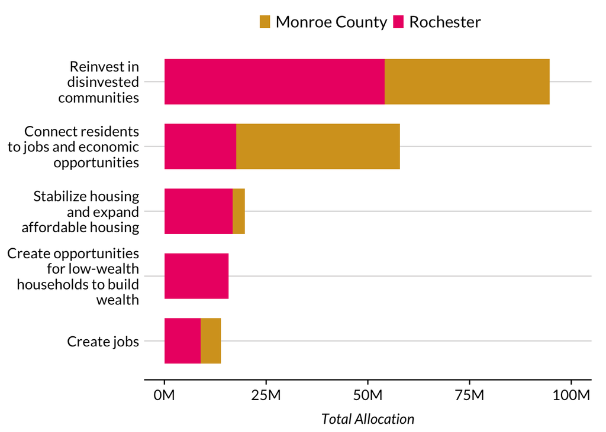

## Funding by Rochester Area Community Foundation Priorities

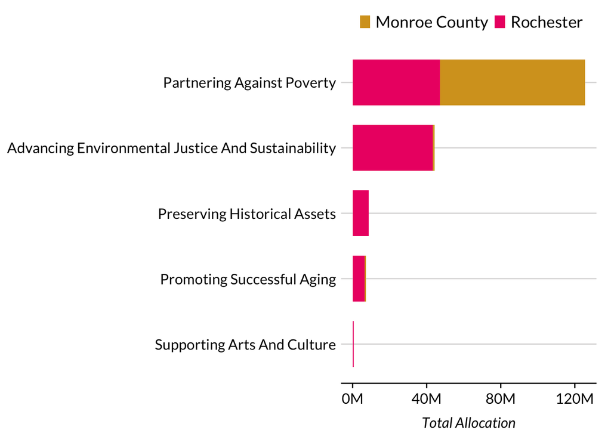

## Explore All Programs Funded

| Program | Program description | Geography | Agency | Topic | Flexible fund | Allocated | Spent | Current as of |
| --- | --- | --- | --- | --- | --- | --- | --- | --- |
| Lead Service Replacement | Replacement of a portion of the city's lead, lead-lined and galvanized water services to remove any possible sources of lead contamination and complete associated street work. | Rochester | Environmental Services | Infrastructure; Reinvest in disinvested communities; Advancing Environmental Justice And Sustainability | Yes | 37315000 | 4858376 | 2023-03-09T00:00:00Z |
| Workforce Development Services and Expansion | Funding will be utilized to provide transformative workforce development experiences for adults and youth. Adult services include paid job training in multiple fields, job placement services, financia… | Rochester | Recreation and Human Services | Community and Economic Development; Connect residents to jobs and economic opportunities; Partnering Against Poverty | Yes | 16675000 | 38400 | 2023-03-09T00:00:00Z |
| Buy the Block - Greenlining for a Better Rochester | New construction of homes for income-eligible, first-time homeowners on vacant lots in Rochester's fomer 'redlined' neighborhoods. | Rochester | Neighborhood and Business Development | Housing; Create opportunities for low-wealth households to build wealth; Partnering Against Poverty | Yes | 13329862 | 7084 | 2023-03-09T00:00:00Z |
| Central Library - Rundel Building Exterior Improvements | Repair, restoration and reconstruction of exterior parapets, limestone and brick masonry, historic windows, and structural framing systems for the east, south and north facades, and repairs to the adj… | Rochester | Environmental Services | Infrastructure; Preserving Historical Assets | Yes | 8700000 | 0 | 2023-03-09T00:00:00Z |
| Parking Fund Revenue Replacement | Replacement of lost government revenues due to the pandemic. Funds will be utilized to support continuation of government services. | Rochester | Finance | Operations | Yes | 8376500 | 5000000 | 2023-03-09T00:00:00Z |
| Roofing Rehabilitation Program | Expansion of the City's high demand roofing assistance program. Funds may cover replacement of roofs, skylights, roof drains, gutters and roofign masonry structure/decking, and parapet reconstruction … | Rochester | Neighborhood and Business Development | Housing; Stabilize housing and expand affordable housing; Partnering Against Poverty | Yes | 7852200 | 1649072 | 2023-03-09T00:00:00Z |
| Neighborhood Collaborative Project (NCP) | Wraparound services and neighborhood outreach via collaboration between well-known community organizations in the crescent. | Monroe County | Community Resource Collaborative on Behalf of the Neighborhood Collaborative Project | Social Services; Reinvest in disinvested communities; Partnering Against Poverty | Yes | 7160849 | NA | 2022-12-22T00:00:00Z |
| Rochester Riverside Convention Center South Terrace Expansion | This ROC the Riverway project encompassing a building addition and modernazation to the southwest face of the RRCC to create a new and revitalized event space that directly engages with the downtown r… | Rochester | Environmental Services | Community and Economic Development | Yes | 6000000 | 62394 | 2023-03-09T00:00:00Z |
| Lead Service Replacement - Homeowner Grant Program | The funds provided will assist residentail property owners in replacing lead service lines in an effort to reduce the amount of lead in drinking water. | Rochester | Neighborhood and Business Development | Housing; Reinvest in disinvested communities; Advancing Environmental Justice And Sustainability | Yes | 6000000 | 0 | 2023-03-09T00:00:00Z |
| Youth Workforce Consortium aka "The Hive" | A collaborative 'Hive' program geared toward BIPOC youth that offers year-round workforce programming, wraparound services and career placement pathways. | Monroe County | EnCompass: Resources for Learning | Community and Economic Development; Connect residents to jobs and economic opportunities; Partnering Against Poverty | Yes | 5869117 | NA | 2022-12-22T00:00:00Z |

[output cut: 81 more lines]

## About the Dashboard

This dashboard was created by the Urban Institute in partnership with and support from The Rochester Area Community Foundation (RACF) to visualize Monroe County and the City of Rochester’s ARPA spending by policy category, the five building blocks of inclusive recovery, and RACF’s investment priorities. By tracking recovery funding expenditures, this dashboard allows us to monitor public spending by the categories most critical in supporting an inclusive recovery from the COVID-19 pandemic.

For more information about the dashboard, please contact Meg Norris (The Rochester Area community Foundation) or Christina Stacy (Urban Institute).

Click For Glossary of Terms

The code used to create this dashboard can be found on GitHub.